# Electric and Non-Electric Car Sales

Annika Shah

02-11-2026

## 1 Loading Libraries

## 2 Research Question

Which countries sold the most electric cars between 2010 and 2025, and how does this compare with their overall car sales? Overall car sales are defined as the total of electric and non-electric car sales.

## 3 Data Set Introduction

This report uses [Number of new cars sold, by type](https://ourworldindata.org/grapher/car-sales), which records the number of new electric and non-electric cars sold between 2010 and 2025 across 60 countries. This data originates from the International Energy Agency’s *Global EV Outlook 2025*, processed by Our World in Data (OWID).

```r
ev_cars <- read_csv("Data/car-sales.csv", show_col_types = FALSE) %>%
  rename(entity = Entity,
         code = Code,
         year = Year,
         electric_cars = `Electric cars`,
         non_electric_cars = `Non-electric cars`) %>%
  filter(!entity %in% c("World", "Europe", "European Union (27)",
                        "Rest of World")) %>%
  drop_na()
```

There are 5 variables: the two character variables are entity (the country of sale) and code (its three-letter country code). The three numeric variables are year (the calendar year of the record), electric_cars and non_electric_cars (the number of new electric and non-electric cars sold in that country and year).

```r
variable_table <- data.frame(Variable = names(ev_cars),
                             Type = sapply(ev_cars, class))

kable(variable_table,
      row.names = FALSE,
      caption = "Variables in the car data set")
```

Table 1: Variables in the car data set

| Variable | Type |
| --- | --- |
| entity | character |
| code | character |
| year | numeric |
| electric_cars | numeric |
| non_electric_cars | numeric |

## 4 Data Set Description

The cleaned data set has 757 observations and 5 variables. Four aggregate regions (World, Europe, European Union (27) and Rest of World) were removed to avoid double-counting, along with two rows with missing values, leaving 60 countries.

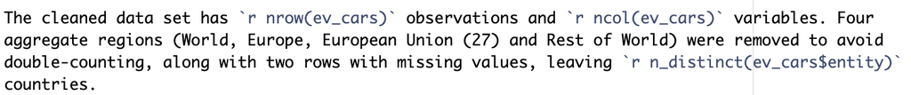

```r
knitr::include_graphics("Image/code-screenshot.png")
```

```r
str(head(ev_cars, 2))
```

```
## tibble [2 × 5] (S3: tbl_df/tbl/data.frame)
##  $ entity           : chr [1:2] "Australia" "Australia"
##  $ code             : chr [1:2] "AUS" "AUS"
##  $ year             : num [1:2] 2011 2012
##  $ electric_cars    : num [1:2] 49 250
##  $ non_electric_cars: num [1:2] 803230 861819
```

## 5 Data Summary

```r
ev_summary <- ev_cars %>%
  select(entity, electric_cars, non_electric_cars) %>%
  group_by(entity) %>%
  summarise(mean_electric = mean(electric_cars),
            total_electric = sum(electric_cars),
            mean_non_electric = mean(non_electric_cars),
            total_non_electric = sum(non_electric_cars)) %>%
  arrange(desc(total_electric)) %>%
  head(6)

kable(ev_summary,
      digits = 0,
      format.args = list(big.mark = ","),
      caption = "Top countries by total electric car sales between 2010 and 2025")
```

Table 2: Top countries by total electric car sales between 2010 and 2025

| entity | mean_electric | total_electric | mean_non_electric | total_non_electric |
| --- | --- | --- | --- | --- |
| China | 2,912,259 | 46,596,150 | 17,046,015 | 272,736,242 |
| United States | 487,188 | 7,795,000 | 13,643,008 | 218,288,132 |
| Germany | 271,342 | 4,341,480 | 2,761,636 | 44,186,181 |
| United Kingdom | 177,140 | 2,834,238 | 1,975,778 | 31,612,449 |
| France | 152,596 | 2,441,538 | 1,848,108 | 29,569,736 |
| Norway | 70,982 | 1,135,720 | 76,832 | 1,229,304 |

**China**, followed by the United States and then Germany, sold the most electric cars between 2010 and 2025. However, even in China, electric sales (46.6 million) are far below non-electric sales (272.7 million), and Norway is the only country shown where the two are close.

```r
share_table <- ev_summary %>%
  mutate(electric_share = 100 * total_electric /
           (total_electric + total_non_electric)) %>%
  select(entity, electric_share)

kable(share_table,
      digits = 1,
      col.names = c("Country", "Electric share of total sales (%)"),
      caption = "Percentage of electric sales during 2010 to 2025")
```

Table 3: Percentage of electric sales during 2010 to 2025

| Country | Electric share of total sales (%) |
| --- | --- |
| China | 14.6 |
| United States | 3.4 |
| Germany | 8.9 |
| United Kingdom | 8.2 |
| France | 7.6 |
| Norway | 48.0 |

Table 3 expresses each country’s electric sales as a percentage of its overall car sales (electric plus non-electric) from 2010 to 2025. Norway’s share is by far the highest of the six countries, at 48.0%, while China, despite having the most electric sales, reaches only 14.6%.

## 6 Visualisations

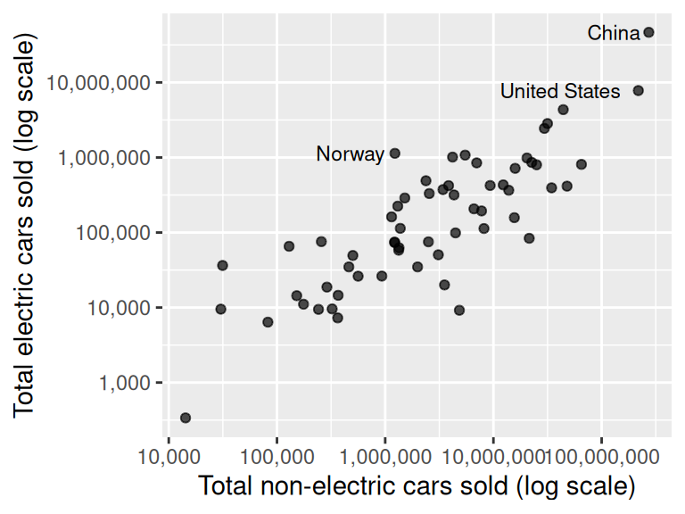

Figure 1: Total electric and non-electric car sales by country, 2010 to 2025

```r
country_totals <- ev_cars %>%
  group_by(entity) %>%
  summarise(total_electric = sum(electric_cars),
            total_non_electric = sum(non_electric_cars))

ggplot(data = country_totals,
       aes(x = total_non_electric, y = total_electric)) +
  geom_point(alpha = 0.7) +
  geom_text(data = filter(country_totals,
                          entity %in% c("China", "United States", "Norway")),
            aes(label = entity),
            hjust = 1.15,
            size = 3) +
  scale_x_log10(labels = scales::comma) +
  scale_y_log10(labels = scales::comma) +
  labs(x = "Total non-electric cars sold (log scale)",
       y = "Total electric cars sold (log scale)")
```

- *Countries with larger non-electric car sales generally also have larger electric car sales, so the points are upward sloping.*
- *China sits at the top right with the highest totals for both, while Norway lies well above the general pattern, with electric sales (1.14 million) close to its non-electric sales (1.23 million).*

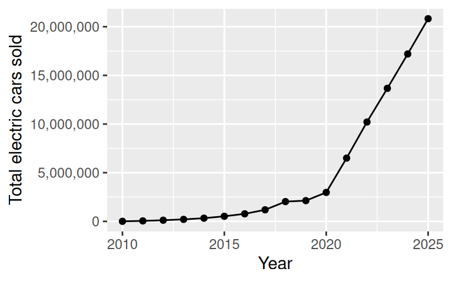

Figure 2: Electric car sales over the period of 2010 to 2025

```r
yearly_totals <- ev_cars %>%
  group_by(year) %>%
  summarise(total_electric = sum(electric_cars))

ggplot(yearly_totals, aes(x = year, y = total_electric)) +
  geom_line() +
  geom_point() +
  scale_y_continuous(labels = scales::comma) +
  labs(x = "Year",
       y = "Total electric cars sold")
```

Figure 2 shows that electric cars sales have steadily increased each year since 2010, reaching over 20 million cars sold in 2025. Part of this growth reflects more countries being recorded over time (19 in 2010 and 59 in 2025).

## 7 Conclusions

China, the United States and Germany sold the most electric cars between 2010 and 2025. Compared with overall car sales, however, electric cars remain a minority in the six leading markets: even in China, electric sales (46.6 million) are far below non-electric sales (272.7 million), an electric share of 14.6%, while only Norway approaches a balance, at 48%. Across all 60 countries, those with larger non-electric sales also tended to sell more electric cars. Total electric car sales increased each year, reaching over 20 million in 2025, although this may partly reflect more countries being recorded over time.